# Assignment 4

Before working on this assignment please read these instructions fully. In the submission area, you will notice that you can click the link to **Preview the Grading** for each step of the assignment. This is the criteria that will be used for peer grading. Please familiarize yourself with the criteria before beginning the assignment.

This assignment requires that you to find **at least** two datasets on the web which are related, and that you visualize these datasets to answer a question with the broad topic of **sports or athletics** (see below) for the region of **Wheaton, Illinois, United States**, or **United States** more broadly.

You can merge these datasets with data from different regions if you like! For instance, you might want to compare **Wheaton, Illinois, United States** to Ann Arbor, USA. In that case at least one source file must be about **Wheaton, Illinois, United States**.

You are welcome to choose datasets at your discretion, but keep in mind **they will be shared with your peers**, so choose appropriate datasets. Sensitive, confidential, illicit, and proprietary materials are not good choices for datasets for this assignment. You are welcome to upload datasets of your own as well, and link to them using a third party repository such as github, bitbucket, pastebin, etc. Please be aware of the Coursera terms of service with respect to intellectual property.

Also, you are welcome to preserve data in its original language, but for the purposes of grading you should provide english translations. You are welcome to provide multiple visuals in different languages if you would like!

As this assignment is for the whole course, you must incorporate principles discussed in the first week, such as having as high data-ink ratio (Tufte) and aligning with Cairo’s principles of truth, beauty, function, and insight.

Here are the assignment instructions:

- State the region and the domain category that your data sets are about (e.g., **Wheaton, Illinois, United States** and **sports or athletics**).
- You must state a question about the domain category and region that you identified as being interesting.
- You must provide at least two links to available datasets. These could be links to files such as CSV or Excel files, or links to websites which might have data in tabular form, such as Wikipedia pages.
- You must upload an image which addresses the research question you stated. In addition to addressing the question, this visual should follow Cairo's principles of truthfulness, functionality, beauty, and insightfulness.
- You must contribute a short (1-2 paragraph) written justification of how your visualization addresses your stated research question.

What do we mean by **sports or athletics**? For this category we are interested in sporting events or athletics broadly, please feel free to creatively interpret the category when building your research question!

## Tips

- Wikipedia is an excellent source of data, and I strongly encourage you to explore it for new data sources.
- Many governments run open data initiatives at the city, region, and country levels, and these are wonderful resources for localized data sources.
- Several international agencies, such as the [United Nations](http://data.un.org/), the [World Bank](http://data.worldbank.org/), the [Global Open Data Index](http://index.okfn.org/place/) are other great places to look for data.
- This assignment requires you to convert and clean datafiles. Check out the discussion forums for tips on how to do this from various sources, and share your successes with your fellow students!

## Example

Looking for an example? Here's what our course assistant put together for the **Ann Arbor, MI, USA** area using **sports and athletics** as the topic. Example Solution File

```python
import os
import matplotlib.pyplot as plt
from matplotlib import style
import numpy as np
import pandas as pd
import sys
from functools import reduce

%matplotlib inline
```

## Create functions

```python
def create_initial_dataframe(team, dct):
    """
    Retrieve dataframes from wikipedia and select the most suitable dataframe
    based on the information given by the dictionary.

    I tested every wikitable separately to create the dictionary "dct".  Additional
    dataframes should be aggreated into the dictionary to make this function work

    """
    page = 'https://en.wikipedia.org/wiki/List_of_Chicago_{}_seasons'.format(team)
    wikitables = pd.read_html(page, flavor='bs4')
    table =wikitables[dct[team]]
    df = pd.DataFrame(table)
    return df


#df = bulls_initial

def bulls_customized_table(df):
    """
    This function makes readable the initial dataframe by pulling just the necessary information
    as well as setting labels for each attribution/column and create a variable called year, if needed.
    Finally a csv is created in case this is needed for future references.

    """
    df = df.loc[:,:8]
    df = df.copy()
    df.columns = df.iloc[0]
    df = df.loc[1:]
    df['Year'] = df['Season'].astype(str).str[:4]
    df.to_csv('bulls_dataframe.csv', index = False)
    return df


#df = bears_initial

def bears_customized_table(df):
    """
    This function makes readable the initial dataframe by pulling just the necessary information
    as well as setting labels for each attribution/column and create a variable called year, if needed.
    Finally a csv is created in case this is needed for future references.

    """
    df = pd.DataFrame(df.loc[51:103,:9])
    # I included this as the resulting dataframe has no columns and just adding columns alone
    # resulted in a dataframe with NaN. By using row_stack I handled this problem
    df = pd.DataFrame(np.row_stack([df.columns, df.values]),
    columns=['Year', 'Season', 'League','Conference', 'Division','Finish', 'Wins', 'Losses', 'Ties', 'Win%'])
    df = df[1:]
    df = df.copy()
    df.to_csv('bears_dataframe.csv', index = False)
    return df


#df = blackhawks_initial

def blackhawks_customized_table(df):
    """
    This function makes readable the initial dataframe by pulling just the necessary information
    as well as setting labels for each attribution/column and create a variable called year, if needed.
    Finally a csv is created in case this is needed for future references.

    """
    df = df.loc[:,:10]
    df = df.copy()
    df.columns = df.iloc[0]
    df =  df.loc[42:94]
    df = df.dropna()
    df['Year'] = df['NHL season'].astype(str).str[:4]
    df.to_csv('blackhawks_dataframe.csv', index = False)
    return df


def cubs_customized_table(df):
    """
    This function makes readable the initial dataframe by pulling just the necessary information
    as well as setting labels for each attribution/column and create a variable called year, if needed.
    Finally a csv is created in case this is needed for future references.

    """
    df = df.loc[:,:8]
    df = df.copy()
    df.columns = df.iloc[0]
    df = df.loc[90:]
    df = df.dropna()
    df['Year'] = df['Season'].astype(str).str[:4]
    df.to_csv('cubs_dataframe.csv', index = False)
    return df


def white_sox_customized_table(df):
    """
    This function makes readable the initial dataframe by pulling just the necessary information
    as well as setting labels for each attribution/column and create a variable called year, if needed.
    Finally a csv is created in case this is needed for future references.

    """
    df = df.loc[:,:8]
    df = df.copy()
    df.columns = df.iloc[0]
    df = df.loc[68:]
    df = df.dropna()
    df['Year'] = df['Season'].astype(str).str[:4]
    df.to_csv('whitesox_dataframe.csv', index = False)
    return df


def calculate_blackhawks_Wins(df):
    """
    The data from wikipedia available in January 2019 does not have the winning ratio available.
    Therefore, this functions takes care of this important step.

    """
    df = df[['Year','W', 'L', 'T']].replace({'—': '0'})
    df = df.apply(pd.to_numeric)
    df['Total'] = df['W'] + df['L'] + df['T']
    df['Win%'] = np.round(df['W'] / df['Total'],3)
    df = df[['Year', 'Win%']]
    return df


def into_a_single_dataframe(dfs):
    """
    By the moment this function is used, we have a list of all the readable dataframes we already collected.
    This function takes care of merging and formatting the resulting dataframe.
    The info from this dataframe will be used to create our graph.

    """
    df_final = reduce(lambda left,right: pd.merge(left,right,on='Year'), dfs)
    df_final = df_final.copy()
    df_final = pd.DataFrame(np.row_stack([df_final.columns, df_final.values]),
                        columns = ['Year','Bulls', 'Bears', 'Blackhawks', 'Cubs', 'White Sox'])
    df_final = np.round(df_final.loc[1:],3).apply(pd.to_numeric)
    df_final.to_csv('final_dataframe.csv', index = False)
    return df_final #.dtypes

def my_graph():
    """
    This function takes the final dataframe to graph the teams in Chicago

    """

    # Create graph canvas
    fig = plt.figure(figsize = (30, 20))
    ax = fig.add_subplot(111)

    # Create x and y parameters
    x = df_final['Year']
    bulls_plot = df_final['Bulls'].rolling(10).mean()
    bears_plot = df_final['Bears'].rolling(10).mean()
    blackhawks_plot = df_final['Blackhawks'].rolling(10).mean()
    cubs_plot = df_final['Cubs'].rolling(10).mean()
    white_sox_plot = df_final['White Sox'].rolling(10).mean()

    # Plot each line
    plt.plot(x, bulls_plot, label = 'Bulls', linewidth = 5)
    plt.plot(x, bears_plot, label = 'Bears', linewidth = 5)
    plt.plot(x, blackhawks_plot, label = 'Blackhawks', linewidth = 5)
    plt.plot(x, cubs_plot, label = 'Cubs', linewidth = 5)
    plt.plot(x, white_sox_plot, label = 'White Sox', linewidth = 5, color = 'grey')

    # Create threshold variables
    threshold_three = 0.75
    threshold_two = 0.5
    threshold_one = 0.25

    # Plot thresholds
    ax.axhline(y = threshold_three, color= 'grey', linestyle = '--')
    ax.axhline(y = threshold_two, color= 'grey', linestyle = '--')
    ax.axhline(y = threshold_one, color= 'grey', linestyle = '--')

    # Define y limits for y.  I used 0 and 1 as the graph had it y axis truncated, which
    # gave a skewed perspective to the graph
    plt.ylim([0, 1])

    # Create labels, titles and legends
    plt.xlabel('Year', fontsize = 26)
    plt.ylabel('10 Year Moving Average Win%', fontsize = 26)
    plt.title('Sports Teams Performance in Chicago \n 10 Year Moving Average 1979 - 2017', fontsize = 33)
    plt.legend(loc = 'best', frameon= False, fontsize= 20)

    # Adjust tick axis size and spines
    plt.tick_params(axis='both', which='major', labelsize=20)
    plt.tick_params(axis='both', which='minor', labelsize=8)

    for i in list(['top', 'right', 'bottom', 'left']):
        plt.gca().spines[i].set_visible(False)

    # Save the resulting graph as a jpg file
    fig.savefig('Sports_In_Chicago.jpg')

    plt.show()

    return
```

## Create variables

```python
dct = {"Bulls": 2, "Bears": 2, "Blackhawks": 1, "Cubs": 1, "White_Sox": 2}
bulls = "Bulls"
bears = "Bears"
blackhawks = "Blackhawks"
cubs = "Cubs"
white_sox = "White_Sox"
```

## Create initial dataframes

```python
bulls_initial = create_initial_dataframe(bulls, dct)
bears_initial = create_initial_dataframe(bears, dct)
blackhawks_initial = create_initial_dataframe(blackhawks, dct)
cubs_initial = create_initial_dataframe(cubs, dct)
white_sox_initial = create_initial_dataframe(white_sox, dct)
```

## Create cleaned dataframes

```python
bulls_readable = bulls_customized_table(bulls_initial)
bears_readable = bears_customized_table(bears_initial)
blackhawks_readable = blackhawks_customized_table(blackhawks_initial)
cubs_readable = cubs_customized_table(cubs_initial)
white_sox_readable = white_sox_customized_table(white_sox_initial)
```

## Create dataframes for graph

```python
bulls_to_graph = bulls_readable[['Year', 'Win%']].apply(pd.to_numeric)
bears_to_graph = bears_readable[['Year', 'Win%']].apply(pd.to_numeric)
blackhawks_to_graph = calculate_blackhawks_Wins(blackhawks_readable)
cubs_to_graph = cubs_readable[['Year', 'Win%']].apply(pd.to_numeric)
white_sox_to_graph = white_sox_readable[['Year', 'Win%']].apply(pd.to_numeric)
```

## Merge data into a single dataframe

```python
dfs = [bulls_to_graph, bears_to_graph, blackhawks_to_graph, cubs_to_graph,white_sox_to_graph]
df_final = into_a_single_dataframe(dfs)
```

## Create Graph

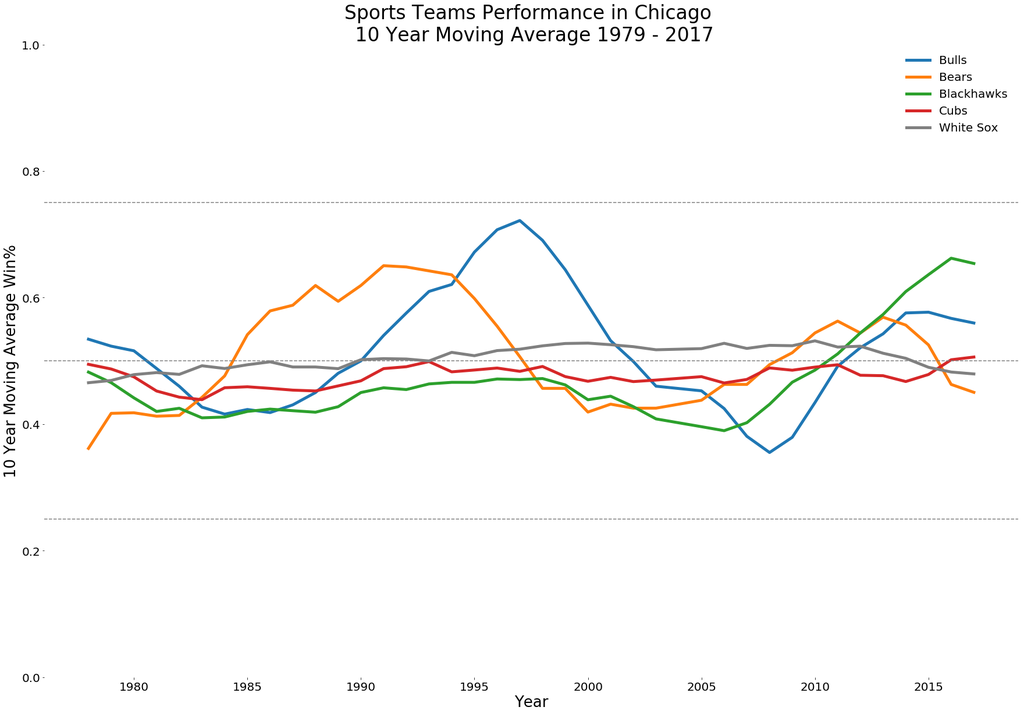

```python
my_graph()
```